# Polygenic risk scores predict hypertension

## 2.5 Early and late onset hypertension.

**Running models**

```r
#Fitting cox for SBP_SCORE
cx.sbp.y <- coxph(Surv(I9_HYPTENS_AGE, HT_EARLY) ~ SBP_CAT + batch + BL_YEAR + PC1 + PC2 + PC3 + PC4 + PC5 + PC6 + PC7 + PC8 + PC9 + PC10, data=df_r)
cx.sbp.o <- coxph(Surv(I9_HYPTENS_AGE, HT_LATE)  ~ SBP_CAT + batch + BL_YEAR + PC1 + PC2 + PC3 + PC4 + PC5 + PC6 + PC7 + PC8 + PC9 + PC10, data=df_r)

#Fitting cox for DBP_SCORE
cx.dbp.y <- coxph(Surv(I9_HYPTENS_AGE, HT_EARLY) ~ DBP_CAT + batch + BL_YEAR + PC1 + PC2 + PC3 + PC4 + PC5 + PC6 + PC7 + PC8 + PC9 + PC10, data=df_r)
cx.dbp.o <- coxph(Surv(I9_HYPTENS_AGE, HT_LATE)  ~ DBP_CAT + batch + BL_YEAR + PC1 + PC2 + PC3 + PC4 + PC5 + PC6 + PC7 + PC8 + PC9 + PC10, data=df_r)
```

**Table: Hazard ratios/early:**

```r
my_hr_table2(cx.sbp.y, cx.dbp.y, "HT_EARLY", df) %>%
  knitr::kable()
```

| PRS | HR (95% CI) | P-value | Cases / Controls |
| --- | --- | --- | --- |
| **SBP** |  |  |  |
| <2.5% | 0.39 (0.35-0.44) | 1.7e-52 | 269 / 5201 |
| 2.5-20% | 0.55 (0.52-0.57) | 2.7e-177 | 2603 / 35684 |
| 20-80% | 1 (reference) | - | 15658 / 115609 |
| 80-97.5% | 1.7 (1.66-1.75) | <1e-300 | 7348 / 30938 |
| >97.5% | 2.62 (2.48-2.77) | 2.5e-271 | 1483 / 3987 |
| **DBP** |  |  |  |
| <2.5% | 0.37 (0.33-0.42) | 3.1e-55 | 256 / 5213 |
| 2.5-20% | 0.56 (0.54-0.59) | 6.6e-162 | 2675 / 35613 |
| 20-80% | 1 (reference) | - | 15527 / 115739 |
| 80-97.5% | 1.73 (1.68-1.78) | <1e-300 | 7351 / 30936 |
| >97.5% | 2.78 (2.64-2.93) | <1e-300 | 1552 / 3918 |

**Table: Hazard ratios/late:**

```r
my_hr_table2(cx.sbp.o, cx.dbp.o, "HT_LATE", df) %>%
  knitr::kable()
```

| PRS | HR (95% CI) | P-value | Cases / Controls |
| --- | --- | --- | --- |
| **SBP** |  |  |  |
| <2.5% | 0.47 (0.43-0.52) | 7.8e-57 | 456 / 5013 |
| 2.5-20% | 0.7 (0.68-0.73) | 3.3e-94 | 4308 / 33972 |
| 20-80% | 1 (reference) | - | 17518 / 113743 |
| 80-97.5% | 1.37 (1.33-1.41) | 1.5e-91 | 5498 / 32788 |
| >97.5% | 1.68 (1.57-1.81) | 2.7e-45 | 776 / 4694 |
| **DBP** |  |  |  |
| <2.5% | 0.57 (0.53-0.63) | 6.7e-38 | 566 / 4902 |
| 2.5-20% | 0.75 (0.73-0.78) | 1.8e-64 | 4640 / 33644 |
| 20-80% | 1 (reference) | - | 17346 / 113910 |
| 80-97.5% | 1.35 (1.31-1.39) | 5e-80 | 5311 / 32977 |
| >97.5% | 1.6 (1.48-1.73) | 2.5e-33 | 693 / 4777 |

## 2.6 Restricted mean survival times

Pairwise statistics between reference risk (20-80% quantile) and each other quantile is are calculated. For this purpose we need separate dataframe for each statistic of interest.

**Creating dataframes for each cases:**

```r
#Run with covariates stalled - only unadjusted analysis is shown.
  covs <- c("SEX_IMPUTED", "BL_YEAR", "PC1", "PC2", "PC3", "PC4", "PC5", "PC6", "PC7", "PC8", "PC9", "PC10")
  #"batch"


#test <- my_extr_cats(cat="SBP_CAT", quant="20-80%", df=df)

q <- c("<2.5%", "2.5-20%", "80-97.5%", ">97.5%" )
df.list.sbp  <-  lapply(q, my_extr_cats, cat="SBP_CAT", covs=covs, df=df)
df.list.dbp  <-  lapply(q, my_extr_cats, cat="DBP_CAT", covs=covs, df=df)
```

**rmst2 is runned for all cases**

Unadjusted analysis - with covariates R is slow and output of this package does not include mean ages for adjusted.

```r
#Unadjusted, this works:

rmst0.sbp <- lapply(df.list.sbp, function(x) rmst2(x$I9_HYPTENS_AGE, x$I9_HYPTENS, x$CAT, tau=95))
rmst0.dbp <- lapply(df.list.dbp, function(x) rmst2(x$I9_HYPTENS_AGE, x$I9_HYPTENS, x$CAT, tau=95))
```

**Results are extracted for the table**

Following results are collected: mean differences, ci’s, pvalues, mean times and their confidence intervals.

```r
#Results extracted:
#

names = c("SBP", "DBP")
rmsts = list(rmst0.sbp, rmst0.dbp)

rmst.diff  <- my_rmst_diffs(names,rmsts)
rmst.means <- my_rmst_means(names,rmsts)
```

Formatting the tables:

```r
#This takes average of reference values in paiwise runs - which is unnecessary, because with the fixed tau the values are the same.
rmst.means.2080 <-
  rbind(
    c("SBP", "20-80%", mean(sapply(rmst0.sbp, function(x) x$RMST.arm0$rmst[1]))),
    c("DBP", "20-80%", mean(sapply(rmst0.dbp, function(x) x$RMST.arm0$rmst[1])))
  ) %>%
  as.tibble() %>%
  rename(name=V1, q=V2, mean=V3)


#We need to add quantile 20 % -80 % to right place
names.for.rmst <-
  rbind(cbind("SBP", levels(df$SBP_CAT)),
        cbind("DBP", levels(df$DBP_CAT))) %>%
  as.tibble() %>%
  rename(name = V1, q = V2)

#Let us combine everything as one table:

rmst.table <-

  names.for.rmst %>%
  left_join(rmst.diff, by=c("name", "q")) %>%
  left_join(rmst.means, by=c("name", "q")) %>%
  left_join(rmst.means.2080, by=c("name", "q")) %>%
  mutate(mean = ifelse(is.na(mean.x), mean.y, mean.x),
         lower_mean = if_else(is.na(lower_mean), mean, lower_mean),
         upper_mean = if_else(is.na(upper_mean), mean, upper_mean)) %>%
  select(-mean.x, -mean.y) %>%
  my_tidy_table("0", 1) %>%
  mutate(est = if_else(q=="20-80%", "0", est)) %>%
  add_row(name="SBP", q="SBP", est="", pval="", lower_mean=NA, upper_mean=NA, mean=NA,  .before = 1) %>%
  add_row(name="",    q="",    est="", pval="", lower_mean=NA, upper_mean=NA, mean=NA,  .before = 7) %>%
  add_row(name="DBP", q="DBP", est="", pval="", lower_mean=NA, upper_mean=NA, mean=NA,  .before = 8)


#rmst.table divided to two and formatted for forestplot

rmst.table.text <- rmst.table %>%
  select(q, est, pval) %>%
  add_row(q=NA, est="Mean difference (95% CI)", pval="P-value", .before = 1)

rmst.table.means <- rmst.table %>%
  select(mean, lower_mean, upper_mean) %>%
  rename(lower = lower_mean, upper=upper_mean) %>%
  add_row(mean=NA, lower=NA, upper=NA, .before = 1)

#rmst.table.text %>% knitr::kable()
```

**Forestplot**

```r
setEPS()
postscript(file = 'rmst_unadj.eps', width = 9, height = 4.5)

my_rmst_plot(rmst.table.text, rmst.table.means,
             clip=c(60,90), xticks = c(60, 65, 70, 75,  80, 85), zero=60)
dev.off()
```

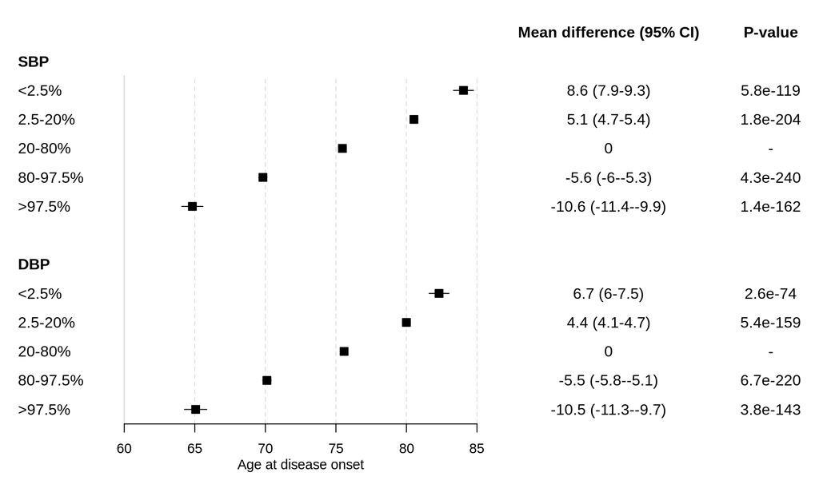

```r
my_rmst_plot(rmst.table.text, rmst.table.means,
             clip=c(60,90), xticks = c(60, 65, 70, 75,  80, 85), zero=60)
```

# 3 BP PRSs and cardiovascular outcomes

## 3.1 Proportional hazard assumption: log log curve:

**Model by survfit**

```r
#SBP
km.sbp.cvd <- survfit(Surv(I9_CVD_HARD_AGE, I9_CVD_HARD) ~ SBP_CAT, data=df)
#print(km.sbp.cvd)

#DBP
km.sbp.chd <- survfit(Surv(I9_CHD_AGE, I9_CHD) ~ SBP_CAT, data=df)
#print(km.sbp.chd)

#PP
km.sbp.str <- survfit(Surv(I9_STR_AGE, I9_STR) ~ SBP_CAT, data=df)
#print(km.sbp.str)
```

**log log curve:**

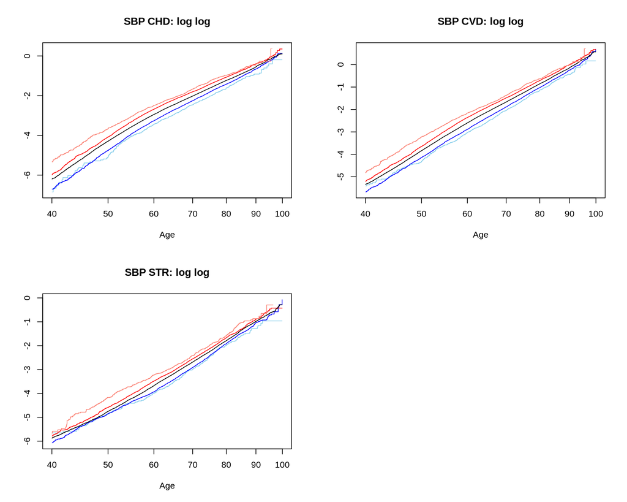

```r
cols= c("skyblue", "blue", "black", "red", "salmon")
labels= c("<2.5%","2.5-20%","20-80%","80-97.5%",">97.5%")

par(mfrow=c(2,2))

plot(km.sbp.chd, fun="cloglog", xlim=c(40,100), main="SBP CHD: log log", xlab="Age", col = cols)
plot(km.sbp.cvd, fun="cloglog", xlim=c(40,100), main="SBP CVD: log log", xlab="Age", col = cols)
plot(km.sbp.str, fun="cloglog", xlim=c(40,100), main="SBP STR: log log", xlab="Age", col = cols)

par(mfrow=c(1,1))
```

These look parallel enough. We can use cox model.

## 3.2 Cox model: covariate adjusted, continuous score

**Running models**

```r
#Fitting cox for SBP_SCORE
cx.sbp.cvd.cs <- coxph(Surv(I9_CVD_HARD_AGE, I9_CVD_HARD) ~ SBP_SCALED + SEX_IMPUTED + batch + BL_YEAR + PC1 + PC2 + PC3 + PC4 + PC5 + PC6 + PC7 + PC8 + PC9 + PC10, data=df)

#Fitting cox for DBP_SCORE
cx.sbp.chd.cs <- coxph(Surv(I9_CHD_AGE, I9_CHD) ~ SBP_SCALED + SEX_IMPUTED + batch + BL_YEAR + PC1 + PC2 + PC3 + PC4 + PC5 + PC6 + PC7 + PC8 + PC9 + PC10, data=df)

#Fitting cox for PP_SCORE
cx.sbp.str.cs <- coxph(Surv(I9_STR_AGE, I9_STR) ~ SBP_SCALED + SEX_IMPUTED + batch + BL_YEAR + PC1 + PC2 + PC3 + PC4 + PC5 + PC6 + PC7 + PC8 + PC9 + PC10, data=df)
```

**Table: Hazard rations:**

For adjusted cox-model.

```r
my_hr_table_cont2(list(cx.sbp.cvd.cs, cx.sbp.chd.cs, cx.sbp.str.cs), c("CVD", "CHD", "Stroke")) %>%
  knitr::kable()
```

| name | HR (95% CI) | P-value |
| --- | --- | --- |
| CVD | 1.13 (1.12-1.15) | 4.3e-95 |
| CHD | 1.15 (1.13-1.17) | 1.3e-85 |
| Stroke | 1.11 (1.09-1.13) | 3e-26 |

**All coefficients**

```r
summary(cx.sbp.cvd.cs)
```

```
## Call:
## coxph(formula = Surv(I9_CVD_HARD_AGE, I9_CVD_HARD) ~ SBP_SCALED +
##     SEX_IMPUTED + batch + BL_YEAR + PC1 + PC2 + PC3 + PC4 + PC5 +
##     PC6 + PC7 + PC8 + PC9 + PC10, data = df)
##
##   n= 218792, number of events= 29350
##
##                                                       coef exp(coef)  se(coef)
## SBP_SCALED                                        0.124739  1.132852  0.006029
## SEX_IMPUTED                                      -0.716795  0.488315  0.012378
## batchAxiomGT1_b02_V2P2.calls                     -0.225332  0.798252  0.071427
## batchAxiomGT1_b03_V2P2.calls                     -0.019264  0.980921  0.075370
## batchAxiomGT1_b04_V2P2.calls                      0.170959  1.186442  0.063836
## batchAxiomGT1_b05_V2P2.calls                     -0.080457  0.922695  0.065375
## batchAxiomGT1_b06_V2P2.calls                     -0.060416  0.941373  0.068440
## batchAxiomGT1_b07_V2P2.calls                      0.034495  1.035097  0.063518
## batchAxiomGT1_b08_V2P2.calls                     -0.002954  0.997050  0.068390
## batchAxiomGT1_b09_V2P2.calls                      0.096146  1.100920  0.071909
## batchAxiomGT1_b10_V2P2.calls                      0.089197  1.093296  0.065168
## batchAxiomGT1_b11_V2P2.calls                      0.233642  1.263192  0.068636
## batchAxiomGT1_b12_V2P2.calls                      0.161596  1.175385  0.085663
## batchAxiomGT1_b13_V2P2.calls                      0.465744  1.593199  0.062913
## batchAxiomGT1_b14_V2P2.calls                      0.228588  1.256824  0.069925
## batchAxiomGT1_b15_V2P2.calls                      0.431285  1.539234  0.070672
## batchAxiomGT1_b16_V2P2.calls                     -0.194613  0.823153  0.096673
## batchAxiomGT1_b17_V2P2.calls                      0.099067  1.104140  0.071526
## batchAxiomGT1_b18_V2P2.calls                      1.114429  3.047829  0.054507
## batchAxiomGT1_b19_V2P2.calls                     -0.396136  0.672915  0.112321
## batchAxiomGT1_b20_V2P2.calls                      0.261867  1.299354  0.065455
## batchAxiomGT1_b21_V2P2.calls                      0.593127  1.809637  0.062753
## batchAxiomGT1_b22_V2P2.calls                      0.350845  1.420267  0.065635
## batchAxiomGT1_b23_V2P2.calls                      0.254022  1.289200  0.070941
## batchAxiomGT1_b24_V2P2.calls                     -0.268700  0.764372  0.103312
## batchAxiomGT1_b25_V2P2.calls                      0.264339  1.302570  0.066759
## batchAxiomGT1_b26_V2P2.calls                      0.393888  1.482734  0.065730
## batchAxiomGT1_b27_V2P2.calls                     -0.534775  0.585801  0.127000
## batchAxiomGT1_b28_V2P2.calls                      0.100858  1.106119  0.071466
## batchAxiomGT1_b29_V2P2.calls                      0.205830  1.228544  0.066837
## batchAxiomGT1_b30_V2P2.calls                      0.128338  1.136937  0.074020
## batchAxiomGT1_b31_V2.calls                       -0.021400  0.978827  0.078498
```

[output cut: 264 more lines]

```
## PC1                                              8.073e-03
## PC2                                              1.717e+02
## PC3                                              1.006e+00
## PC4                                              6.428e-01
## PC5                                              8.833e-01
## PC6                                              2.732e+00
## PC7                                              8.352e+00
## PC8                                              2.197e+01
## PC9                                              2.019e+00
## PC10                                             7.716e-01
##
## Concordance= 0.692  (se = 0.002 )
## Likelihood ratio test= 13341  on 75 df,   p=<2e-16
## Wald test            = 15820  on 75 df,   p=<2e-16
## Score (logrank) test = 19199  on 75 df,   p=<2e-16
```

```r
summary(cx.sbp.chd.cs)
```

```
## Call:
## coxph(formula = Surv(I9_CHD_AGE, I9_CHD) ~ SBP_SCALED + SEX_IMPUTED +
##     batch + BL_YEAR + PC1 + PC2 + PC3 + PC4 + PC5 + PC6 + PC7 +
##     PC8 + PC9 + PC10, data = df)
##
##   n= 218792, number of events= 21012
##
##                                                        coef  exp(coef)
## SBP_SCALED                                         0.139727   1.149960
## SEX_IMPUTED                                       -0.889953   0.410675
## batchAxiomGT1_b02_V2P2.calls                      -0.245937   0.781972
## batchAxiomGT1_b03_V2P2.calls                      -0.090424   0.913544
## batchAxiomGT1_b04_V2P2.calls                      -0.005635   0.994381
## batchAxiomGT1_b05_V2P2.calls                      -0.217777   0.804305
## batchAxiomGT1_b06_V2P2.calls                      -0.209768   0.810772
## batchAxiomGT1_b07_V2P2.calls                      -0.125129   0.882383
## batchAxiomGT1_b08_V2P2.calls                      -0.168030   0.845328
## batchAxiomGT1_b09_V2P2.calls                       0.032876   1.033422
## batchAxiomGT1_b10_V2P2.calls                      -0.006310   0.993709
## batchAxiomGT1_b11_V2P2.calls                       0.202149   1.224030
## batchAxiomGT1_b12_V2P2.calls                       0.014614   1.014721
## batchAxiomGT1_b13_V2P2.calls                       0.518886   1.680156
## batchAxiomGT1_b14_V2P2.calls                       0.116646   1.123721
## batchAxiomGT1_b15_V2P2.calls                       0.520301   1.682534
## batchAxiomGT1_b16_V2P2.calls                      -0.143477   0.866341
## batchAxiomGT1_b17_V2P2.calls                       0.053907   1.055386
## batchAxiomGT1_b18_V2P2.calls                       1.296494   3.656453
## batchAxiomGT1_b19_V2P2.calls                      -0.523574   0.592399
## batchAxiomGT1_b20_V2P2.calls                       0.214887   1.239722
## batchAxiomGT1_b21_V2P2.calls                       0.706527   2.026940
## batchAxiomGT1_b22_V2P2.calls                       0.379266   1.461212
## batchAxiomGT1_b23_V2P2.calls                       0.153773   1.166226
## batchAxiomGT1_b24_V2P2.calls                      -0.408931   0.664360
## batchAxiomGT1_b25_V2P2.calls                       0.291419   1.338325
## batchAxiomGT1_b26_V2P2.calls                       0.277603   1.319962
## batchAxiomGT1_b27_V2P2.calls                      -0.655333   0.519269
## batchAxiomGT1_b28_V2P2.calls                       0.074986   1.077869
## batchAxiomGT1_b29_V2P2.calls                       0.220476   1.246670
## batchAxiomGT1_b30_V2P2.calls                       0.149530   1.161289
## batchAxiomGT1_b31_V2.calls                         0.008479   1.008515
```

[output cut: 340 more lines]

```
## PC1                                              2.109e-03
## PC2                                              7.876e+02
## PC3                                              2.765e+00
## PC4                                              9.913e-01
## PC5                                              5.405e-01
## PC6                                              9.359e+00
## PC7                                              1.390e+01
## PC8                                              2.619e+01
## PC9                                              3.376e+00
## PC10                                             3.279e-01
##
## Concordance= 0.735  (se = 0.002 )
## Likelihood ratio test= 14633  on 75 df,   p=<2e-16
## Wald test            = 17952  on 75 df,   p=<2e-16
## Score (logrank) test = 24250  on 75 df,   p=<2e-16
```

```r
summary(cx.sbp.str.cs)
```

```
## Call:
## coxph(formula = Surv(I9_STR_AGE, I9_STR) ~ SBP_SCALED + SEX_IMPUTED +
##     batch + BL_YEAR + PC1 + PC2 + PC3 + PC4 + PC5 + PC6 + PC7 +
##     PC8 + PC9 + PC10, data = df)
##
##   n= 212884, number of events= 11734
##    (5908 observations deleted due to missingness)
##
##                                                       coef exp(coef)  se(coef)
## SBP_SCALED                                        0.101164  1.106459  0.009545
## SEX_IMPUTED                                      -0.368124  0.692032  0.019043
## batchAxiomGT1_b02_V2P2.calls                     -0.163480  0.849184  0.115818
## batchAxiomGT1_b03_V2P2.calls                      0.147647  1.159104  0.118893
## batchAxiomGT1_b04_V2P2.calls                      0.442834  1.557113  0.099701
## batchAxiomGT1_b05_V2P2.calls                      0.176090  1.192546  0.102987
## batchAxiomGT1_b06_V2P2.calls                      0.219437  1.245375  0.106586
## batchAxiomGT1_b07_V2P2.calls                      0.319767  1.376807  0.100307
## batchAxiomGT1_b08_V2P2.calls                      0.296273  1.344837  0.106052
## batchAxiomGT1_b09_V2P2.calls                      0.267212  1.306318  0.114514
## batchAxiomGT1_b10_V2P2.calls                      0.343827  1.410334  0.102804
## batchAxiomGT1_b11_V2P2.calls                      0.298854  1.348313  0.111241
## batchAxiomGT1_b12_V2P2.calls                      0.473550  1.605684  0.129733
## batchAxiomGT1_b13_V2P2.calls                      0.376531  1.457220  0.104848
## batchAxiomGT1_b14_V2P2.calls                      0.415445  1.515044  0.109029
## batchAxiomGT1_b15_V2P2.calls                      0.247513  1.280836  0.120329
## batchAxiomGT1_b16_V2P2.calls                     -0.182441  0.833234  0.155905
## batchAxiomGT1_b17_V2P2.calls                      0.219254  1.245147  0.113281
## batchAxiomGT1_b18_V2P2.calls                      0.578774  1.783849  0.093114
## batchAxiomGT1_b19_V2P2.calls                     -0.109742  0.896065  0.165274
## batchAxiomGT1_b20_V2P2.calls                      0.369662  1.447245  0.105038
## batchAxiomGT1_b21_V2P2.calls                      0.434045  1.543489  0.104277
## batchAxiomGT1_b22_V2P2.calls                      0.344927  1.411887  0.106172
## batchAxiomGT1_b23_V2P2.calls                      0.418158  1.519161  0.110463
## batchAxiomGT1_b24_V2P2.calls                      0.053679  1.055146  0.150385
## batchAxiomGT1_b25_V2P2.calls                      0.283963  1.328384  0.108931
## batchAxiomGT1_b26_V2P2.calls                      0.630011  1.877631  0.103248
## batchAxiomGT1_b27_V2P2.calls                     -0.295523  0.744142  0.189588
## batchAxiomGT1_b28_V2P2.calls                      0.146864  1.158197  0.115616
## batchAxiomGT1_b29_V2P2.calls                      0.209889  1.233541  0.109369
## batchAxiomGT1_b30_V2P2.calls                      0.132395  1.141559  0.120545
```

[output cut: 265 more lines]

```
## PC1                                                 0.1827
## PC2                                                17.0768
## PC3                                                 0.6069
## PC4                                                 0.9571
## PC5                                                 6.2676
## PC6                                                 2.1472
## PC7                                                19.7384
## PC8                                                18.4111
## PC9                                                 8.0900
## PC10                                               21.8228
##
## Concordance= 0.62  (se = 0.003 )
## Likelihood ratio test= 1720  on 75 df,   p=<2e-16
## Wald test            = 1788  on 75 df,   p=<2e-16
## Score (logrank) test = 1880  on 75 df,   p=<2e-16
```

## 3.3 Cox model: covariate adjusted, categorized score

**Running models**

```r
#Fitting cox for CVD_HARD vs. SBP_CAT
cx.sbp.cvd <- coxph(Surv(I9_CVD_HARD_AGE, I9_CVD_HARD) ~ SBP_CAT + SEX_IMPUTED + batch + BL_YEAR + PC1 + PC2 + PC3 + PC4 + PC5 + PC6 + PC7 + PC8 + PC9 + PC10, data=df_r)

#Fitting cox for CHD vs. SBP_CAT
cx.sbp.chd <- coxph(Surv(I9_CHD_AGE, I9_CHD) ~ SBP_CAT + SEX_IMPUTED + batch + BL_YEAR + PC1 + PC2 + PC3 + PC4 + PC5 + PC6 + PC7 + PC8 + PC9 + PC10, data=df_r)

#Fitting cox for STR vs. SBP_CAT
cx.sbp.str <- coxph(Surv(I9_STR_AGE, I9_STR) ~ SBP_CAT + SEX_IMPUTED + batch + BL_YEAR + PC1 + PC2 + PC3 + PC4 + PC5 + PC6 + PC7 + PC8 + PC9 + PC10, data=df_r)
```

**Table: Hazard rations:**

```r
my_hr_table_cvd2(cx.sbp.cvd, cx.sbp.chd, cx.sbp.str, "SBP_CAT", df) %>%
  knitr::kable()
```

[output not shown]

**All coefficients**

```r
summary(cx.sbp.cvd)
```

```
## Call:
## coxph(formula = Surv(I9_CVD_HARD_AGE, I9_CVD_HARD) ~ SBP_CAT +
##     SEX_IMPUTED + batch + BL_YEAR + PC1 + PC2 + PC3 + PC4 + PC5 +
##     PC6 + PC7 + PC8 + PC9 + PC10, data = df_r)
##
##   n= 218792, number of events= 29350
##
##                                                       coef exp(coef)  se(coef)
## SBP_CAT<2.5%                                     -0.307519  0.735269  0.042413
## SBP_CAT2.5-20%                                   -0.171927  0.842040  0.016856
## SBP_CAT80-97.5%                                   0.151974  1.164129  0.015281
## SBP_CAT>97.5%                                     0.263628  1.301644  0.034125
## SEX_IMPUTED                                      -0.716814  0.488306  0.012378
## batchAxiomGT1_b02_V2P2.calls                     -0.226939  0.796969  0.071430
## batchAxiomGT1_b03_V2P2.calls                     -0.021024  0.979196  0.075369
## batchAxiomGT1_b04_V2P2.calls                      0.170598  1.186014  0.063839
## batchAxiomGT1_b05_V2P2.calls                     -0.081156  0.922050  0.065378
## batchAxiomGT1_b06_V2P2.calls                     -0.061332  0.940511  0.068440
## batchAxiomGT1_b07_V2P2.calls                      0.031569  1.032072  0.063521
## batchAxiomGT1_b08_V2P2.calls                     -0.004757  0.995255  0.068393
## batchAxiomGT1_b09_V2P2.calls                      0.094618  1.099239  0.071908
## batchAxiomGT1_b10_V2P2.calls                      0.088210  1.092218  0.065168
## batchAxiomGT1_b11_V2P2.calls                      0.232687  1.261986  0.068638
## batchAxiomGT1_b12_V2P2.calls                      0.159473  1.172893  0.085663
## batchAxiomGT1_b13_V2P2.calls                      0.461569  1.586562  0.062914
## batchAxiomGT1_b14_V2P2.calls                      0.228342  1.256514  0.069926
## batchAxiomGT1_b15_V2P2.calls                      0.427921  1.534065  0.070673
## batchAxiomGT1_b16_V2P2.calls                     -0.195461  0.822456  0.096676
## batchAxiomGT1_b17_V2P2.calls                      0.096754  1.101590  0.071525
## batchAxiomGT1_b18_V2P2.calls                      1.115364  3.050678  0.054507
## batchAxiomGT1_b19_V2P2.calls                     -0.398820  0.671111  0.112323
## batchAxiomGT1_b20_V2P2.calls                      0.259575  1.296378  0.065457
## batchAxiomGT1_b21_V2P2.calls                      0.592704  1.808873  0.062754
## batchAxiomGT1_b22_V2P2.calls                      0.350330  1.419536  0.065635
## batchAxiomGT1_b23_V2P2.calls                      0.253894  1.289035  0.070944
## batchAxiomGT1_b24_V2P2.calls                     -0.271475  0.762254  0.103312
## batchAxiomGT1_b25_V2P2.calls                      0.263067  1.300914  0.066757
## batchAxiomGT1_b26_V2P2.calls                      0.393325  1.481900  0.065729
## batchAxiomGT1_b27_V2P2.calls                     -0.536138  0.585003  0.127000
## batchAxiomGT1_b28_V2P2.calls                      0.098545  1.103565  0.071467
```

[output cut: 276 more lines]

```
## PC1                                                0.00744
## PC2                                              166.33138
## PC3                                                1.05446
## PC4                                                0.83157
## PC5                                                0.89575
## PC6                                                2.52878
## PC7                                                8.70511
## PC8                                               22.13572
## PC9                                                1.98182
## PC10                                               1.33903
##
## Concordance= 0.691  (se = 0.002 )
## Likelihood ratio test= 13279  on 78 df,   p=<2e-16
## Wald test            = 15750  on 78 df,   p=<2e-16
## Score (logrank) test = 19133  on 78 df,   p=<2e-16
```

```r
summary(cx.sbp.chd)
```

```
## Call:
## coxph(formula = Surv(I9_CHD_AGE, I9_CHD) ~ SBP_CAT + SEX_IMPUTED +
##     batch + BL_YEAR + PC1 + PC2 + PC3 + PC4 + PC5 + PC6 + PC7 +
##     PC8 + PC9 + PC10, data = df_r)
##
##   n= 218792, number of events= 21012
##
##                                                        coef  exp(coef)
## SBP_CAT<2.5%                                      -0.377622   0.685489
## SBP_CAT2.5-20%                                    -0.180020   0.835253
## SBP_CAT80-97.5%                                    0.179048   1.196078
## SBP_CAT>97.5%                                      0.286906   1.332298
## SEX_IMPUTED                                       -0.890077   0.410624
## batchAxiomGT1_b02_V2P2.calls                      -0.247392   0.780835
## batchAxiomGT1_b03_V2P2.calls                      -0.092152   0.911966
## batchAxiomGT1_b04_V2P2.calls                      -0.005556   0.994459
## batchAxiomGT1_b05_V2P2.calls                      -0.218408   0.803797
## batchAxiomGT1_b06_V2P2.calls                      -0.210653   0.810055
## batchAxiomGT1_b07_V2P2.calls                      -0.127351   0.880425
## batchAxiomGT1_b08_V2P2.calls                      -0.169730   0.843893
## batchAxiomGT1_b09_V2P2.calls                       0.030551   1.031023
## batchAxiomGT1_b10_V2P2.calls                      -0.007062   0.992962
## batchAxiomGT1_b11_V2P2.calls                       0.201514   1.223253
## batchAxiomGT1_b12_V2P2.calls                       0.012794   1.012876
## batchAxiomGT1_b13_V2P2.calls                       0.514334   1.672525
## batchAxiomGT1_b14_V2P2.calls                       0.116931   1.124042
## batchAxiomGT1_b15_V2P2.calls                       0.516867   1.676766
## batchAxiomGT1_b16_V2P2.calls                      -0.143874   0.865997
## batchAxiomGT1_b17_V2P2.calls                       0.052237   1.053626
## batchAxiomGT1_b18_V2P2.calls                       1.298033   3.662086
## batchAxiomGT1_b19_V2P2.calls                      -0.527050   0.590344
## batchAxiomGT1_b20_V2P2.calls                       0.213343   1.237809
## batchAxiomGT1_b21_V2P2.calls                       0.706291   2.026462
## batchAxiomGT1_b22_V2P2.calls                       0.378695   1.460378
## batchAxiomGT1_b23_V2P2.calls                       0.154160   1.166678
## batchAxiomGT1_b24_V2P2.calls                      -0.411689   0.662530
## batchAxiomGT1_b25_V2P2.calls                       0.290651   1.337298
## batchAxiomGT1_b26_V2P2.calls                       0.277077   1.319268
## batchAxiomGT1_b27_V2P2.calls                      -0.656239   0.518799
## batchAxiomGT1_b28_V2P2.calls                       0.073401   1.076162
```

[output cut: 355 more lines]

```
## PC1                                              1.935e-03
## PC2                                              7.635e+02
## PC3                                              2.912e+00
## PC4                                              1.299e+00
## PC5                                              5.467e-01
## PC6                                              8.578e+00
## PC7                                              1.468e+01
## PC8                                              2.600e+01
## PC9                                              3.271e+00
## PC10                                             6.045e-01
##
## Concordance= 0.734  (se = 0.002 )
## Likelihood ratio test= 14579  on 78 df,   p=<2e-16
## Wald test            = 17885  on 78 df,   p=<2e-16
## Score (logrank) test = 24190  on 78 df,   p=<2e-16
```

```r
summary(cx.sbp.str)
```

```
## Call:
## coxph(formula = Surv(I9_STR_AGE, I9_STR) ~ SBP_CAT + SEX_IMPUTED +
##     batch + BL_YEAR + PC1 + PC2 + PC3 + PC4 + PC5 + PC6 + PC7 +
##     PC8 + PC9 + PC10, data = df_r)
##
##   n= 212884, number of events= 11734
##    (5908 observations deleted due to missingness)
##
##                                                       coef exp(coef)  se(coef)
## SBP_CAT<2.5%                                     -0.229831  0.794668  0.065144
## SBP_CAT2.5-20%                                   -0.146821  0.863448  0.026391
## SBP_CAT80-97.5%                                   0.104813  1.110503  0.024496
## SBP_CAT>97.5%                                     0.255491  1.291095  0.053949
## SEX_IMPUTED                                      -0.367587  0.692403  0.019043
## batchAxiomGT1_b02_V2P2.calls                     -0.164909  0.847971  0.115822
## batchAxiomGT1_b03_V2P2.calls                      0.146104  1.157317  0.118892
## batchAxiomGT1_b04_V2P2.calls                      0.442290  1.556267  0.099704
## batchAxiomGT1_b05_V2P2.calls                      0.175103  1.191369  0.102988
## batchAxiomGT1_b06_V2P2.calls                      0.218436  1.244130  0.106587
## batchAxiomGT1_b07_V2P2.calls                      0.315779  1.371327  0.100313
## batchAxiomGT1_b08_V2P2.calls                      0.294395  1.342314  0.106056
## batchAxiomGT1_b09_V2P2.calls                      0.266557  1.305462  0.114515
## batchAxiomGT1_b10_V2P2.calls                      0.342473  1.408426  0.102806
## batchAxiomGT1_b11_V2P2.calls                      0.297923  1.347058  0.111245
## batchAxiomGT1_b12_V2P2.calls                      0.471353  1.602161  0.129735
## batchAxiomGT1_b13_V2P2.calls                      0.372976  1.452050  0.104852
## batchAxiomGT1_b14_V2P2.calls                      0.415339  1.514884  0.109031
## batchAxiomGT1_b15_V2P2.calls                      0.245289  1.277990  0.120332
## batchAxiomGT1_b16_V2P2.calls                     -0.183477  0.832371  0.155912
## batchAxiomGT1_b17_V2P2.calls                      0.216128  1.241261  0.113281
## batchAxiomGT1_b18_V2P2.calls                      0.579106  1.784442  0.093117
## batchAxiomGT1_b19_V2P2.calls                     -0.111698  0.894314  0.165277
## batchAxiomGT1_b20_V2P2.calls                      0.367374  1.443938  0.105041
## batchAxiomGT1_b21_V2P2.calls                      0.434196  1.543722  0.104279
## batchAxiomGT1_b22_V2P2.calls                      0.345240  1.412328  0.106176
## batchAxiomGT1_b23_V2P2.calls                      0.416311  1.516357  0.110470
## batchAxiomGT1_b24_V2P2.calls                      0.050833  1.052147  0.150383
## batchAxiomGT1_b25_V2P2.calls                      0.282450  1.326376  0.108929
## batchAxiomGT1_b26_V2P2.calls                      0.628643  1.875065  0.103248
## batchAxiomGT1_b27_V2P2.calls                     -0.296951  0.743081  0.189589
```

[output cut: 277 more lines]

```
## PC1                                                 0.1704
## PC2                                                16.6575
## PC3                                                 0.6396
## PC4                                                 1.1965
## PC5                                                 6.4732
## PC6                                                 1.9810
## PC7                                                20.4509
## PC8                                                18.5109
## PC9                                                 7.9762
## PC10                                               35.1769
##
## Concordance= 0.62  (se = 0.003 )
## Likelihood ratio test= 1704  on 78 df,   p=<2e-16
## Wald test            = 1772  on 78 df,   p=<2e-16
## Score (logrank) test = 1864  on 78 df,   p=<2e-16
```

**Selecting covariates for plot**

We used **mean** values for all numeric variables. For ‘batch’, we use batch with **low significance** for all variables.

**Choosing covariate values**

```r
sbp.coefs <-  summary(cx.sbp.cvd)$coefficients %>%
  as.data.frame() %>%
  mutate(name = row.names(.)) %>%
  rename(pval="Pr(>|z|)") %>%
  select("name", "coef", "exp(coef)","se(coef)", "pval")

#Let's look bit more on batches to select a one for the figure
batch.coefs <- sbp.coefs %>%
  arrange(pval)

batch.coefs  #Let's print out this

#Käytetään batchiä:  AxiomGT1_b36_V2.calls, matala kaikissa.
```

[output not shown]

**Cox-plot: covariate adjusted, categorized score**

```r
df.sbp.cvd <- my_expand(cx.sbp.cvd, "SBP_CAT", df, batch = "AxiomGT1_b36_V2.calls")
df.sbp.chd <- my_expand(cx.sbp.chd, "SBP_CAT", df, batch = "AxiomGT1_b36_V2.calls")
df.sbp.str <- my_expand(cx.sbp.str, "SBP_CAT", df, batch = "AxiomGT1_b36_V2.calls")

fit.sbp.cvd <- survfit(cx.sbp.cvd, newdata = df.sbp.cvd)
fit.sbp.chd <- survfit(cx.sbp.chd, newdata = df.sbp.chd)
fit.sbp.str <- survfit(cx.sbp.str, newdata = df.sbp.str)
```

And the plot:

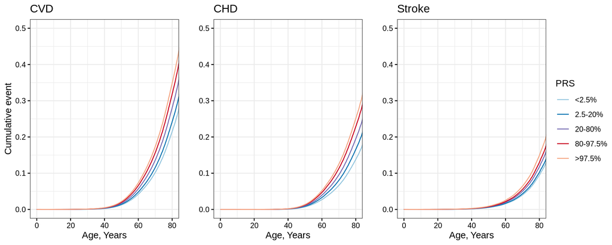

```r
p.cvd <- my_ggcoxplot(fit.sbp.cvd, df.sbp.cvd, "CVD", conf.int = F, ylim=c(0,0.5), legend="none")
p.chd <- my_ggcoxplot(fit.sbp.chd, df.sbp.chd,  "CHD", conf.int = F, ylim=c(0,0.5), legend="none", ylab="")
p.str <- my_ggcoxplot(fit.sbp.str, df.sbp.str, "Stroke", conf.int = F, ylim=c(0,0.5), legend="none", ylab="")


p.tmp <-  my_ggcoxplot(fit.sbp.cvd, df.sbp.cvd, "CVD", conf.int = F, ylim=c(0,0.5), legend="right")

#From survminer format to ggplot format:
p1 <- p.cvd$plot
p2 <- p.chd$plot
p3 <- p.str$plot

lgnd <- get_legend(p.tmp$plot)

splots <- grid.arrange(p1, p2, p3, lgnd, nrow = 1, widths = c(3,3,3,1))
```

```r
ggsave(file = "cx_cvd_prs.png", plot = splots, height = 3, width = 10, dpi = 150)
ggsave(file = "cx_cvd_prs.pdf", plot = splots, height = 3, width = 10, dpi = 150)
ggsave(file = "cx_cvd_prs.eps", plot = splots, height = 3, width = 10, dpi = 150)
```

# 4 Restricted mean survival times

## 4.1 All data

Pairwise statistics between reference risk (20-80% quantile) and each other quantile is are calculated. For this purpose we need separate dataframe for each statistic of interest.

**Creating dataframes for each cases:**

```r
#Run with covariates stalled - only unadjusted analysis is shown.

q <- c("<2.5%", "2.5-20%", "80-97.5%", ">97.5%" )
df.list.cvd  <-  lapply(q, my_extr_cats, endpoints=c("I9_CVD_HARD_AGE", "I9_CVD_HARD"), cat="SBP_CAT", df=df)
df.list.chd  <-  lapply(q, my_extr_cats, endpoints=c("I9_CHD_AGE", "I9_CHD"), cat="SBP_CAT", df=df)
df.list.str  <-  lapply(q, my_extr_cats, endpoints=c("I9_STR_AGE", "I9_STR"), cat="SBP_CAT", df=df)
```

**rmst2 is runned for all cases**

Unadjusted analysis - with covariates R stalls. Propably too large dataset. [The new version of package faster]

```r
#Unadjusted, this works:

rmst0.cvd <- lapply(df.list.cvd, function(x) rmst2(x$I9_CVD_HARD_AGE, x$I9_CVD_HARD, x$CAT, tau=95))
rmst0.chd <- lapply(df.list.chd, function(x) rmst2(x$I9_CHD_AGE, x$I9_CHD, x$CAT, tau=95))
rmst0.str  <- lapply(df.list.str, function(x) rmst2(x$I9_STR_AGE, x$I9_STR, x$CAT, tau=95))
```

**Results are extracted for the table**

Following results are collected: mean differences, ci’s, pvalues, mean times and their confidence intervals.

```r
#Results extracted:
#

names = c("CVD", "CHD", "STR")
rmsts = list(rmst0.cvd, rmst0.chd, rmst0.str)

rmst.diffs.cvd  <- my_rmst_diffs(names,rmsts)
rmst.means.cvd <- my_rmst_means(names,rmsts)
```

Formatting the tables:

```r
#This takes average of reference values in paiwise runs - which is unnecessary, because with the fixed tau the values are the same.
rmst.means.2080.cvd <-
  rbind(
    c("CVD", "20-80%", mean(sapply(rmst0.cvd, function(x) x$RMST.arm0$rmst[1]))),
    c("CHD", "20-80%", mean(sapply(rmst0.chd, function(x) x$RMST.arm0$rmst[1]))),
    c("STR", "20-80%", mean(sapply(rmst0.str, function(x) x$RMST.arm0$rmst[1])))
  ) %>%
  as.tibble() %>%
  rename(name=V1, q=V2, mean=V3)


#We need to add quantile 20 % -80 % to right place
names.for.rmst.cvd <-
  rbind(cbind("CVD", levels(df$SBP_CAT)),
        cbind("CHD", levels(df$SBP_CAT)),
        cbind("STR", levels(df$SBP_CAT))) %>%
  as.tibble() %>%
  rename(name = V1, q = V2)

#Let us combine everything as one table:

rmst.table <-

  names.for.rmst.cvd %>%
  left_join(rmst.diffs.cvd, by=c("name", "q")) %>%
  left_join(rmst.means.cvd, by=c("name", "q")) %>%
  left_join(rmst.means.2080.cvd, by=c("name", "q")) %>%
  mutate(mean = ifelse(is.na(mean.x), mean.y, mean.x),
         lower_mean = if_else(is.na(lower_mean), mean, lower_mean),
         upper_mean = if_else(is.na(upper_mean), mean, upper_mean)) %>%
  select(-mean.x, -mean.y) %>%
  my_tidy_table("0", 1) %>%
  mutate(est = if_else(q=="20-80%", "0", est)) %>%
  add_row(name="CVD", q="CVD", est="", pval="", lower_mean=NA, upper_mean=NA, mean=NA,  .before = 1) %>%
  add_row(name="",    q="",    est="", pval="", lower_mean=NA, upper_mean=NA, mean=NA,  .before = 7) %>%
  add_row(name="CHD", q="CHD", est="", pval="", lower_mean=NA, upper_mean=NA, mean=NA,  .before = 8) %>%
  add_row(name="",    q="",    est="", pval="", lower_mean=NA, upper_mean=NA, mean=NA,   .before = 14)%>%
  add_row(name="Stroke", q="Stroke", est="", pval="", lower_mean=NA, upper_mean=NA, mean=NA,   .before = 15)


#rmst.table divided to two and formatted for forestplot

rmst.table.text.cvd <- rmst.table %>%
  select(q, est, pval) %>%
  add_row(q=NA, est="Mean difference (95% CI)", pval="P-value", .before = 1)

rmst.table.means.cvd <- rmst.table %>%
  select(mean, lower_mean, upper_mean) %>%
  rename(lower = lower_mean, upper=upper_mean) %>%
  add_row(mean=NA, lower=NA, upper=NA, .before = 1)

#rmst.table.text %>% knitr::kable()
```

**Forestplot**

```r
#Forestplot

setEPS()
postscript(file = 'rmst_cvd_unadj.eps', width = 9, height = 6)

my_rmst_plot(rmst.table.text.cvd, rmst.table.means.cvd,
             clip=c(78,91), xticks = c(80, 85, 90), zero=80)
dev.off()
```

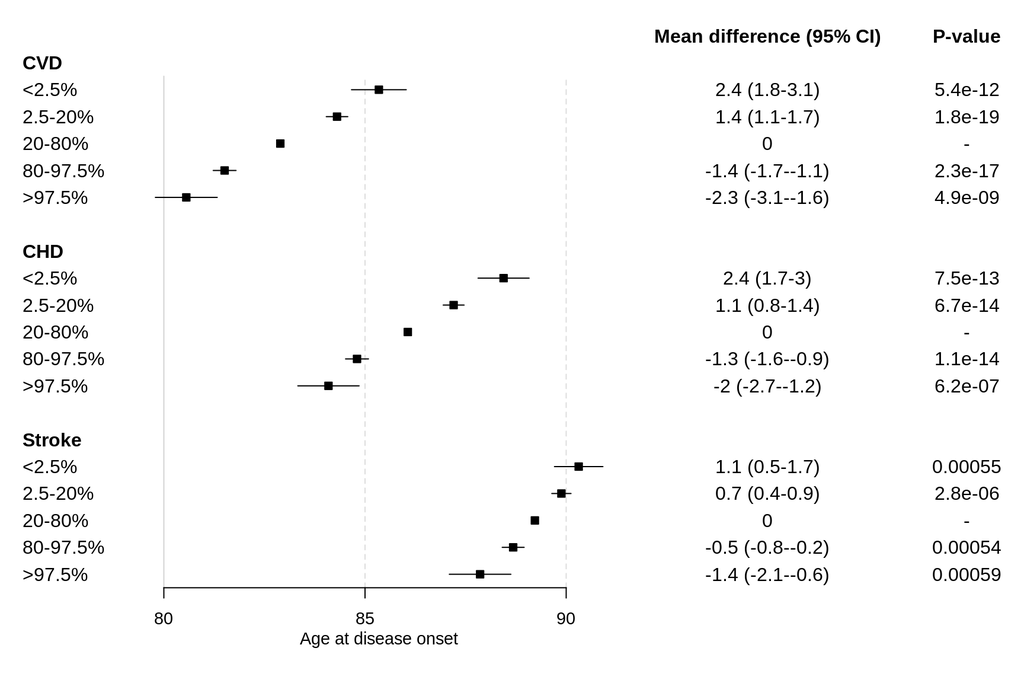

```r
my_rmst_plot(rmst.table.text.cvd, rmst.table.means.cvd,
             clip=c(78,91), xticks = c(80, 85, 90), zero=80)
```